# Tuango - RFM Analysis for Mobile App Push Messaging

- Name:
- GitLab id:
- GitLab username:

## Setup

Please complete this R-markdown document by answering the questions in `tuango.pdf` on Dropbox (week4/readings/). The code block below will load the data you will need for this first Rmarkdown file. Create a Notebook/HTML file with all your results and answers and push both the Rmarkdown and Notebook/HTML file to GitLab when you are done. All results MUST be reproducible (i.e., the TA and I must be able to recreate the Notebook/HTML from the R-markdown file without changes or errors).

```r
## loading the data. Note that data must be loaded from Dropbox/MGTA455-2019/data
library(dplyr)
tuango <- readr::read_rds(file.path(radiant.data::find_dropbox(), "MGTA455-2019/data/tuango.rds"))
buyer<- tuango %>%
  group_by(buyer)%>%
  summarize(n=n())
buyer_percentage <-as.numeric(buyer[1,2]/(buyer[2,2]+buyer[1,2]))
buyer_percentage
```

```
[1] 0.02980845
```

Question 1 0.0298

```r
amount_spent <- tuango %>%
  filter(buyer == 'yes')
amount_spent<- mean(amount_spent$ordersize)
amount_spent
```

```
[1] 202.1288
```

Question2 202.1288

```r
tuango <- tuango %>%
  mutate(rec_iq = radiant.data::xtile(recency, 5))%>%
  mutate(freq_iq = radiant.data::xtile(frequency,5,rev=TRUE))%>%
  mutate(mon_iq = radiant.data::xtile(monetary,5,rev=TRUE))
```

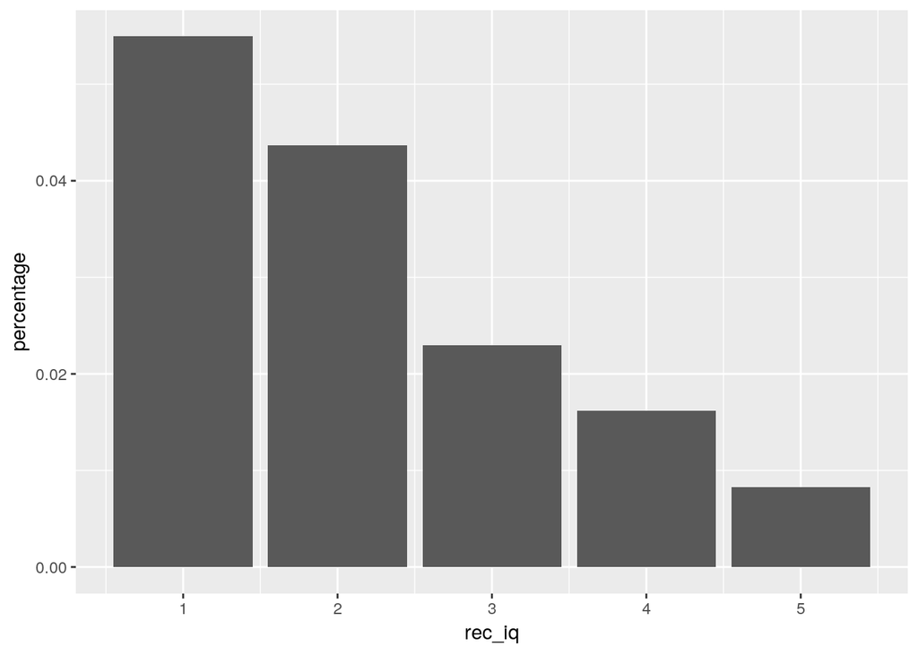

```r
rec1 <- tuango %>%
  mutate(buyer = as.numeric(buyer))%>%
  filter(buyer == 1)%>%
  group_by(rec_iq)%>%
  summarize(n= sum(buyer))
plot1 <- tuango%>%
  group_by(rec_iq)%>%
  summarize(n2 = n())%>%
  right_join(rec1,by='rec_iq')%>%
  mutate(percentage= n/n2)%>%
  ggplot(aes(rec_iq,percentage))+geom_bar(stat='identity')
freq1 <- tuango %>%
  mutate(buyer = as.numeric(buyer))%>%
  filter(buyer == 1)%>%
  group_by(freq_iq)%>%
  summarize(n= sum(buyer))
plot2 <- tuango%>%
  group_by(freq_iq)%>%
  summarize(n2 = n())%>%
  right_join(freq1,by='freq_iq')%>%
  mutate(percentage= n/n2)%>%
  ggplot(aes(freq_iq,percentage))+geom_bar(stat='identity')
mon1 <- tuango %>%
  mutate(buyer = as.numeric(buyer))%>%
  filter(buyer == 1)%>%
  group_by(mon_iq)%>%
  summarize(n= sum(buyer))
plot3 <- tuango%>%
  group_by(mon_iq)%>%
  summarize(n2 = n())%>%
  right_join(mon1,by='mon_iq')%>%
  mutate(percentage= n/n2)%>%
  ggplot(aes(mon_iq,percentage))+geom_bar(stat='identity')
show(plot1)
```

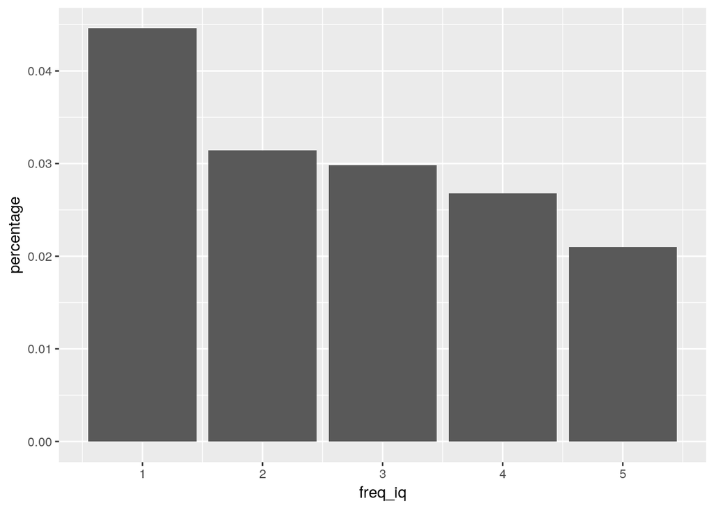

```r
show(plot2)
```

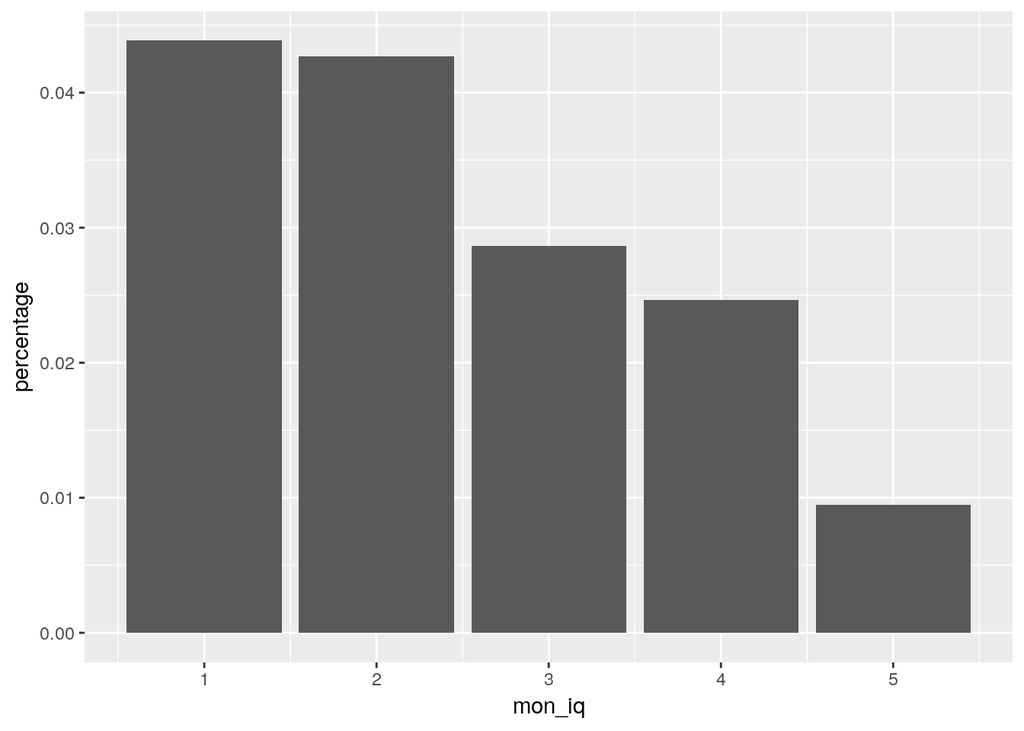

```r
show(plot3)
```